# Práctica II

## 1. Obtención de los datos

### Funciones de utilidad

Importación de las librerías necesarias

```python
import seaborn as sns
import pandas as pd
import numpy as np
from scipy import stats
from scipy.stats import pearsonr
from scipy.stats import levene
import matplotlib.pyplot as plt
import statsmodels.api as sm
from scipy.stats import shapiro
from scipy.stats import bartlett
from scipy.stats import norm



from sklearn.linear_model import LinearRegression
from sklearn.model_selection import train_test_split
from sklearn.metrics import r2_score
from sklearn.metrics import mean_squared_error
```

Función **`export_dataframe`** que permite exportar el dataframe a fichero CSV

```python
def export_dataframe( df, file_name, directory ):
    file = 'C:\Python_Projects\TipologiaYCicloDeVidaDelDato\Data\%s/%s.csv' % (directory, file_name )
    #file = '/home/jovyan/work/%s/%s.csv' % (directory, file_name )
    df.to_csv(file )
```

```python
def read_dataframe( file_name, directory ):
    file = 'C:\Python_Projects\TipologiaYCicloDeVidaDelDato\Data\%s/%s.csv' % (directory, file_name )
    #file = '/home/jovyan/work/%s/%s.csv' % (directory, file_name )
    return pd.read_csv(file )
```

```python
def read_subdataframe( file_name ):
    return read_dataframe(
        file_name = file_name,
        directory = 'subdataset'
    ).iloc[ : , 1:]
```

### *DATASET I*: Precio de Gas doméstico en € por kw/h

Obtención de los datos del subdataset de los precios del gas doméstico: `data_gas_prices_household_consumers.csv`

Importación del subdataframe

```python
data_gas_prices_household_consumers = read_subdataframe(
    file_name = 'data_gas_prices_household_consumers'
)
```

Columnas del dataset:

```python
display( data_gas_prices_household_consumers.dtypes )
```

```
country          object
country_name     object
2017            float64
2018            float64
2019            float64
2020            float64
2021            float64
dtype: object
```

Se muestran los 10 primeros valores:

```python
data_gas_prices_household_consumers.head( 10 )
```

|  | country | country_name | 2017 | 2018 | 2019 | 2020 | 2021 |
| --- | --- | --- | --- | --- | --- | --- | --- |
| 0 | AT | Austria | 0.0299 | 0.0304 | 0.0312 | 0.0308 | 0.0316 |
| 1 | BA | Bosnia and Herzegovina | 0.0240 | 0.0240 | 0.0249 | 0.0258 | 0.0251 |
| 2 | BE | Belgium | 0.0283 | 0.0288 | 0.0289 | 0.0252 | 0.0315 |
| 3 | BG | Bulgaria | 0.0170 | 0.0209 | 0.0240 | 0.0177 | 0.0331 |
| 4 | CZ | Czechia | 0.0360 | 0.0390 | 0.0455 | 0.0431 | 0.0448 |
| 5 | DE | Germany (until 1990 former territory of the FRG) | NaN | NaN | 0.0278 | 0.0292 | 0.0293 |
| 6 | DK | Denmark | 0.0234 | 0.0259 | 0.0209 | 0.0160 | 0.0415 |
| 7 | EA | Euro area (EA11-1999, EA12-2001, EA13-2007, EA... | 0.0295 | 0.0303 | 0.0319 | 0.0302 | 0.0315 |
| 8 | EE | Estonia | 0.0234 | 0.0239 | 0.0253 | 0.0240 | 0.0361 |
| 9 | EL | Greece | NaN | 0.0311 | 0.0338 | 0.0258 | 0.0444 |

### *DATASET II*: Precio de Gas no doméstico en € por kw/h

Obtención de los datos del subdataset de los precios del gas no doméstico: `data_gas_prices_no_household_consumers.csv`

Importación del subdataframe

```python
data_gas_prices_no_household_consumers = read_subdataframe(
    file_name = 'data_gas_prices_no_household_consumers'
)
```

Columnas del dataset:

```python
display( data_gas_prices_no_household_consumers.dtypes )
```

```
country          object
country_name     object
2017            float64
2018            float64
2019            float64
2020            float64
2021            float64
dtype: object
```

Se muestran los 10 primeros valores:

```python
data_gas_prices_no_household_consumers.head( 10 )
```

|  | country | country_name | 2017 | 2018 | 2019 | 2020 | 2021 |
| --- | --- | --- | --- | --- | --- | --- | --- |
| 0 | AT | Austria | NaN | NaN | 0.0184 | 0.0168 | 0.0297 |
| 1 | BA | Bosnia and Herzegovina | NaN | NaN | 0.0257 | 0.0259 | 0.0248 |
| 2 | BE | Belgium | NaN | NaN | 0.0189 | 0.0148 | 0.0318 |
| 3 | BG | Bulgaria | NaN | NaN | 0.0213 | 0.0142 | 0.0299 |
| 4 | CZ | Czechia | NaN | NaN | 0.0226 | 0.0192 | 0.0259 |
| 5 | DE | Germany (until 1990 former territory of the FRG) | NaN | NaN | 0.0196 | 0.0171 | 0.0262 |
| 6 | DK | Denmark | 0.0194 | 0.0234 | 0.0178 | 0.0137 | 0.0448 |
| 7 | EA | Euro area (EA11-1999, EA12-2001, EA13-2007, EA... | 0.0220 | 0.0240 | 0.0211 | 0.0175 | 0.0278 |
| 8 | EE | Estonia | NaN | NaN | 0.0213 | 0.0155 | 0.0352 |
| 9 | EL | Greece | NaN | NaN | 0.0260 | 0.0165 | 0.0337 |

### *DATASET III*: Precio de la electricidad doméstica para la franja de 2.500 a 4.999 kWh

Obtención de los datos del subdataset del precio de la electricidad doméstica para la franja de 2.500 a 4.999 kWh `data_electricity_prices_household_consumers.csv`

Importación del subdataframe

```python
data_electricity_prices_household_consumers = read_subdataframe(
    file_name = 'data_electricity_prices_household_consumers'
)
```

Columnas del dataset:

```python
display( data_electricity_prices_household_consumers.dtypes )
```

```
country          object
country_name     object
2012-S2         float64
2013-S2         float64
2014-S2         float64
2015-S2         float64
2016-S2         float64
2017            float64
2018            float64
2019            float64
2020            float64
2021            float64
dtype: object
```

Se muestran los 10 primeros valores:

```python
data_electricity_prices_household_consumers.head(10)
```

|  | country | country_name | 2012-S2 | 2013-S2 | 2014-S2 | 2015-S2 | 2016-S2 | 2017 | 2018 | 2019 | 2020 | 2021 |
| --- | --- | --- | --- | --- | --- | --- | --- | --- | --- | --- | --- | --- |
| 0 | AL | Albania | NaN | NaN | NaN | NaN | NaN | 0.0713 | 0.0759 | 0.0778 | NaN | 0.0781 |
| 1 | AT | Austria | NaN | NaN | NaN | NaN | NaN | 0.0613 | 0.0623 | 0.0687 | 0.0732 | 0.0745 |
| 2 | BA | Bosnia and Herzegovina | NaN | NaN | NaN | NaN | NaN | 0.0342 | 0.0338 | 0.0361 | 0.0365 | NaN |
| 3 | BE | Belgium | NaN | NaN | NaN | NaN | NaN | 0.0735 | 0.0808 | 0.0859 | 0.0786 | 0.0844 |
| 4 | BG | Bulgaria | NaN | NaN | NaN | NaN | NaN | 0.0575 | 0.0585 | 0.0558 | 0.0560 | 0.0608 |
| 5 | CY | Cyprus | NaN | NaN | NaN | NaN | NaN | 0.1036 | 0.1157 | 0.1241 | 0.1042 | 0.1094 |
| 6 | CZ | Czechia | NaN | NaN | NaN | NaN | NaN | 0.0541 | 0.0570 | 0.0690 | 0.0749 | 0.0979 |
| 7 | DE | Germany (until 1990 former territory of the FRG) | NaN | NaN | NaN | NaN | NaN | 0.0686 | 0.0622 | 0.0581 | 0.0574 | 0.0803 |
| 8 | DK | Denmark | NaN | NaN | NaN | NaN | NaN | 0.0388 | 0.0503 | 0.0539 | 0.0409 | 0.0747 |
| 9 | EA | Euro area (EA11-1999, EA12-2001, EA13-2007, EA... | NaN | NaN | NaN | NaN | NaN | 0.0760 | 0.0801 | 0.0727 | 0.0697 | 0.0898 |

### *DATASET IV*: Precio de la electricidad no doméstica

OObtención de los datos del subdataset del precio de la electricidad no doméstica `data_electricity_prices_no_household_consumers.csv`

Importación del subdataframe

```python
data_electricity_prices_no_household_consumers = read_subdataframe(
    file_name = 'data_electricity_prices_no_household_consumers'
)
```

Columnas del dataset:

```python
display( data_electricity_prices_no_household_consumers.dtypes )
```

```
country          object
country_name     object
2007-S2         float64
2008-S2         float64
2009-S2         float64
2010-S2         float64
2011-S2         float64
2012-S2         float64
2013-S2         float64
2014-S2         float64
2015-S2         float64
2016-S2         float64
2017            float64
2018            float64
2019            float64
2020            float64
2021            float64
dtype: object
```

Se muestran los 10 primeros valores:

```python
data_electricity_prices_no_household_consumers.head( 10 )
```

|  | country | country_name | 2007-S2 | 2008-S2 | 2009-S2 | 2010-S2 | 2011-S2 | 2012-S2 | 2013-S2 | 2014-S2 | 2015-S2 | 2016-S2 | 2017 | 2018 | 2019 | 2020 | 2021 |
| --- | --- | --- | --- | --- | --- | --- | --- | --- | --- | --- | --- | --- | --- | --- | --- | --- | --- |
| 0 | AT | Austria | NaN | NaN | NaN | NaN | NaN | NaN | NaN | NaN | NaN | NaN | 0.0598 | 0.0610 | 0.0654 | 0.0702 | 0.0723 |
| 1 | BA | Bosnia and Herzegovina | NaN | NaN | NaN | NaN | NaN | NaN | NaN | NaN | NaN | NaN | 0.0649 | 0.0621 | 0.0624 | 0.0648 | NaN |
| 2 | BE | Belgium | NaN | NaN | NaN | NaN | NaN | NaN | NaN | NaN | NaN | NaN | 0.0672 | 0.0624 | 0.0663 | 0.0745 | 0.0890 |
| 3 | BG | Bulgaria | NaN | NaN | NaN | NaN | NaN | NaN | NaN | NaN | NaN | NaN | 0.0817 | 0.0810 | 0.0764 | 0.0730 | 0.1075 |
| 4 | CY | Cyprus | NaN | NaN | NaN | NaN | NaN | NaN | NaN | NaN | NaN | NaN | 0.1187 | 0.1240 | 0.1271 | 0.1055 | 0.1136 |
| 5 | CZ | Czechia | NaN | NaN | NaN | NaN | NaN | NaN | NaN | NaN | NaN | NaN | 0.0580 | 0.0602 | 0.0721 | 0.0811 | 0.0848 |
| 6 | DE | Germany (until 1990 former territory of the FRG) | NaN | NaN | NaN | NaN | NaN | NaN | NaN | NaN | NaN | NaN | 0.0468 | 0.0612 | 0.0525 | 0.0651 | 0.0707 |
| 7 | DK | Denmark | NaN | NaN | NaN | NaN | NaN | NaN | NaN | NaN | NaN | NaN | 0.0433 | 0.0514 | 0.0517 | 0.0426 | 0.0898 |
| 8 | EA | Euro area (EA11-1999, EA12-2001, EA13-2007, EA... | NaN | NaN | NaN | NaN | NaN | NaN | NaN | NaN | NaN | NaN | 0.0757 | 0.0837 | 0.0794 | 0.0780 | 0.0893 |
| 9 | EE | Estonia | NaN | NaN | NaN | NaN | NaN | NaN | NaN | NaN | NaN | NaN | 0.0406 | 0.0489 | 0.0516 | 0.0440 | 0.0850 |

## 2. Análisis inicial y procesamiento de los datos

### Funciones de utilidad

```python
def median_estimator( df, column ) :
    median = df.loc[pd.notnull( df[column]), column].median()
    df[column].fillna(median,inplace=True)
    return df
```

Función **`show_boxplot`** que muestra el diagrama de caja de los valores de un dataframe

```python
def show_boxplot( df ):
    sns.set_theme( style = "whitegrid" )
    ax = sns.boxplot( data = df )
```

Función **`init_outlier`**. Iializa el Outlier de una columna, inicializa a nulo el valor máximo de la columna

```python
def init_outlier(df, column):
    df.loc[
        df[column] == df[column].max(),
        column
    ] = np.nan
    return df
```

### Datos de los costes del gas doméstico

```python
GasPricesHousehold=data_gas_prices_household_consumers

GasPricesHousehold = median_estimator( GasPricesHousehold, '2021' )
GasPricesHousehold = median_estimator( GasPricesHousehold, '2020' )
GasPricesHousehold = median_estimator( GasPricesHousehold, '2019' )
GasPricesHousehold = median_estimator( GasPricesHousehold, '2018' )
GasPricesHousehold = median_estimator( GasPricesHousehold, '2017' )
```

Se muestran los 10 primeros valores:

```python
display( GasPricesHousehold.head(10) )
```

|  | country | country_name | 2017 | 2018 | 2019 | 2020 | 2021 |
| --- | --- | --- | --- | --- | --- | --- | --- |
| 0 | AT | Austria | 0.0299 | 0.0304 | 0.0312 | 0.0308 | 0.0316 |
| 1 | BA | Bosnia and Herzegovina | 0.0240 | 0.0240 | 0.0249 | 0.0258 | 0.0251 |
| 2 | BE | Belgium | 0.0283 | 0.0288 | 0.0289 | 0.0252 | 0.0315 |
| 3 | BG | Bulgaria | 0.0170 | 0.0209 | 0.0240 | 0.0177 | 0.0331 |
| 4 | CZ | Czechia | 0.0360 | 0.0390 | 0.0455 | 0.0431 | 0.0448 |
| 5 | DE | Germany (until 1990 former territory of the FRG) | 0.0243 | 0.0254 | 0.0278 | 0.0292 | 0.0293 |
| 6 | DK | Denmark | 0.0234 | 0.0259 | 0.0209 | 0.0160 | 0.0415 |
| 7 | EA | Euro area (EA11-1999, EA12-2001, EA13-2007, EA... | 0.0295 | 0.0303 | 0.0319 | 0.0302 | 0.0315 |
| 8 | EE | Estonia | 0.0234 | 0.0239 | 0.0253 | 0.0240 | 0.0361 |
| 9 | EL | Greece | 0.0243 | 0.0311 | 0.0338 | 0.0258 | 0.0444 |

Diagrama de caja para los diferentes años:

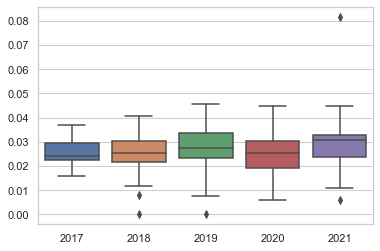

```python
show_boxplot( GasPricesHousehold )
```

### Datos de los costes del gas para empresas

```python
GasPricesNoHousehold = data_gas_prices_no_household_consumers

GasPricesNoHousehold = median_estimator( GasPricesNoHousehold, '2021' )
GasPricesNoHousehold = median_estimator( GasPricesNoHousehold, '2020' )
GasPricesNoHousehold = median_estimator( GasPricesNoHousehold, '2019' )
GasPricesNoHousehold = median_estimator( GasPricesNoHousehold, '2018' )
GasPricesNoHousehold = median_estimator( GasPricesNoHousehold, '2017' )
```

Se muestran los 10 primero valores:

```python
display( GasPricesNoHousehold.head(10) )
```

|  | country | country_name | 2017 | 2018 | 2019 | 2020 | 2021 |
| --- | --- | --- | --- | --- | --- | --- | --- |
| 0 | AT | Austria | 0.0220 | 0.0240 | 0.0184 | 0.0168 | 0.0297 |
| 1 | BA | Bosnia and Herzegovina | 0.0220 | 0.0240 | 0.0257 | 0.0259 | 0.0248 |
| 2 | BE | Belgium | 0.0220 | 0.0240 | 0.0189 | 0.0148 | 0.0318 |
| 3 | BG | Bulgaria | 0.0220 | 0.0240 | 0.0213 | 0.0142 | 0.0299 |
| 4 | CZ | Czechia | 0.0220 | 0.0240 | 0.0226 | 0.0192 | 0.0259 |
| 5 | DE | Germany (until 1990 former territory of the FRG) | 0.0220 | 0.0240 | 0.0196 | 0.0171 | 0.0262 |
| 6 | DK | Denmark | 0.0194 | 0.0234 | 0.0178 | 0.0137 | 0.0448 |
| 7 | EA | Euro area (EA11-1999, EA12-2001, EA13-2007, EA... | 0.0220 | 0.0240 | 0.0211 | 0.0175 | 0.0278 |
| 8 | EE | Estonia | 0.0220 | 0.0240 | 0.0213 | 0.0155 | 0.0352 |
| 9 | EL | Greece | 0.0220 | 0.0240 | 0.0260 | 0.0165 | 0.0337 |

Diagrama de caja para los diferentes años:

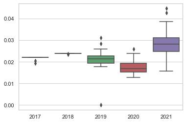

```python
show_boxplot( GasPricesNoHousehold )
```

### Datos de los costes de la electricidad doméstica

Se eliminan las columnas correspondientes a los valores semestrales de lo años desde el 2012 al 2016 que no contienen datos

```python
ElectPricesHouseholds = data_electricity_prices_household_consumers.drop(
    [
     '2012-S2',
     '2013-S2',
     '2014-S2',
     '2015-S2',
     '2016-S2'
    ], axis=1
)
```

Muestra de los 10 primeros valores

```python
display( ElectPricesHouseholds.head( 10 ) )
```

|  | country | country_name | 2017 | 2018 | 2019 | 2020 | 2021 |
| --- | --- | --- | --- | --- | --- | --- | --- |
| 0 | AL | Albania | 0.0713 | 0.0759 | 0.0778 | NaN | 0.0781 |
| 1 | AT | Austria | 0.0613 | 0.0623 | 0.0687 | 0.0732 | 0.0745 |
| 2 | BA | Bosnia and Herzegovina | 0.0342 | 0.0338 | 0.0361 | 0.0365 | NaN |
| 3 | BE | Belgium | 0.0735 | 0.0808 | 0.0859 | 0.0786 | 0.0844 |
| 4 | BG | Bulgaria | 0.0575 | 0.0585 | 0.0558 | 0.0560 | 0.0608 |
| 5 | CY | Cyprus | 0.1036 | 0.1157 | 0.1241 | 0.1042 | 0.1094 |
| 6 | CZ | Czechia | 0.0541 | 0.0570 | 0.0690 | 0.0749 | 0.0979 |
| 7 | DE | Germany (until 1990 former territory of the FRG) | 0.0686 | 0.0622 | 0.0581 | 0.0574 | 0.0803 |
| 8 | DK | Denmark | 0.0388 | 0.0503 | 0.0539 | 0.0409 | 0.0747 |
| 9 | EA | Euro area (EA11-1999, EA12-2001, EA13-2007, EA... | 0.0760 | 0.0801 | 0.0727 | 0.0697 | 0.0898 |

Se muestra el diagrama de caja

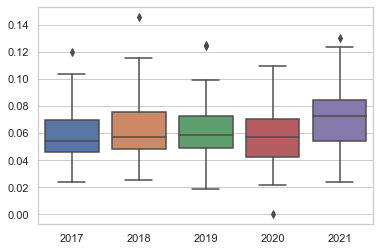

```python
show_boxplot( ElectPricesHouseholds )
```

Detectamos Outlier en el año 2021, inicializamos valor

```python
ElectPricesHouseholds = init_outlier(ElectPricesHouseholds, '2021')
```

```python
ElectPricesHouseholds = median_estimator( ElectPricesHouseholds, '2021' )
ElectPricesHouseholds = median_estimator( ElectPricesHouseholds, '2020' )
ElectPricesHouseholds = median_estimator( ElectPricesHouseholds, '2019' )
ElectPricesHouseholds = median_estimator( ElectPricesHouseholds, '2018' )
ElectPricesHouseholds = median_estimator( ElectPricesHouseholds, '2017' )
```

Se vuelve a mostrar el diagrama de caja

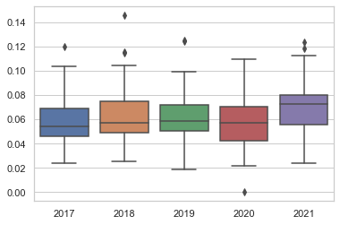

```python
show_boxplot( ElectPricesHouseholds )
```

### Datos de los costes de la electricidad para empresas

```python
ElectPricesNoHouseholds = data_electricity_prices_no_household_consumers.drop(
    [
        '2007-S2',
        '2008-S2',
        '2009-S2',
        '2010-S2',
        '2011-S2',
        '2012-S2',
        '2013-S2',
        '2014-S2',
        '2015-S2',
        '2016-S2'
    ], axis=1
)
```

Se muestra el diagrama de caja

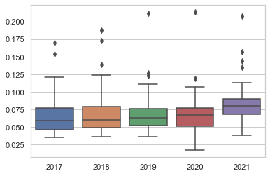

```python
show_boxplot( ElectPricesNoHouseholds )
```

Muestra de los 10 primeros valores

```python
display( ElectPricesNoHouseholds.head( 10 ) )
```

|  | country | country_name | 2017 | 2018 | 2019 | 2020 | 2021 |
| --- | --- | --- | --- | --- | --- | --- | --- |
| 0 | AT | Austria | 0.0598 | 0.0610 | 0.0654 | 0.0702 | 0.0723 |
| 1 | BA | Bosnia and Herzegovina | 0.0649 | 0.0621 | 0.0624 | 0.0648 | NaN |
| 2 | BE | Belgium | 0.0672 | 0.0624 | 0.0663 | 0.0745 | 0.0890 |
| 3 | BG | Bulgaria | 0.0817 | 0.0810 | 0.0764 | 0.0730 | 0.1075 |
| 4 | CY | Cyprus | 0.1187 | 0.1240 | 0.1271 | 0.1055 | 0.1136 |
| 5 | CZ | Czechia | 0.0580 | 0.0602 | 0.0721 | 0.0811 | 0.0848 |
| 6 | DE | Germany (until 1990 former territory of the FRG) | 0.0468 | 0.0612 | 0.0525 | 0.0651 | 0.0707 |
| 7 | DK | Denmark | 0.0433 | 0.0514 | 0.0517 | 0.0426 | 0.0898 |
| 8 | EA | Euro area (EA11-1999, EA12-2001, EA13-2007, EA... | 0.0757 | 0.0837 | 0.0794 | 0.0780 | 0.0893 |
| 9 | EE | Estonia | 0.0406 | 0.0489 | 0.0516 | 0.0440 | 0.0850 |

Detectamos Outlier en los valores del 2021 y lo inicializamos

```python
ElectPricesHouseholds = init_outlier(ElectPricesNoHouseholds, '2021')
```

```python
ElectPricesNoHouseholds = median_estimator( ElectPricesNoHouseholds, '2021' )
ElectPricesNoHouseholds = median_estimator( ElectPricesNoHouseholds, '2020' )
ElectPricesNoHouseholds = median_estimator( ElectPricesNoHouseholds, '2019' )
ElectPricesNoHouseholds = median_estimator( ElectPricesNoHouseholds, '2018' )
ElectPricesNoHouseholds = median_estimator( ElectPricesNoHouseholds, '2017' )
```

Se vuelve a mostrar el diagrama de caja

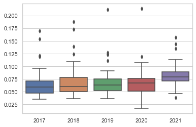

```python
show_boxplot( ElectPricesNoHouseholds )
```

### *Conclusión de análisis inicial de datos:*

Descartamos continuar el análisis del "Gas" en el caso de los precios de los consumos de las empresas, ya que los datos obtenidos son una muestra demasiado pequeña, en concreto en los años 2017 y 2018 (ver dataset data_gas_prices_no_household_consumers.csv).

Generamos El Dataset final a exportar, con los datos posibles

```python
dElectCol = pd.merge(
    ElectPricesHouseholds,
    ElectPricesNoHouseholds.drop(['country_name'], axis=1),
    on='country',
    suffixes=('_ElectHouse', '_ElectNoHouse')
)

dGasCol = pd.merge(
    GasPricesHousehold.drop(['country_name'], axis=1),
    GasPricesNoHousehold.drop(['country_name'], axis=1),
    on='country',
    suffixes=('_GasHouse', '_GasNoHouse')
)

dEnergyCol = pd.merge(
    dElectCol,
    dGasCol,
    on='country'
)
```

Mostramos el dataset final a publicar:

```python
dEnergyCol.head()
```

|  | country | country_name | 2017_ElectHouse | 2018_ElectHouse | 2019_ElectHouse | 2020_ElectHouse | 2021_ElectHouse | 2017_ElectNoHouse | 2018_ElectNoHouse | 2019_ElectNoHouse | ... | 2017_GasHouse | 2018_GasHouse | 2019_GasHouse | 2020_GasHouse | 2021_GasHouse | 2017_GasNoHouse | 2018_GasNoHouse | 2019_GasNoHouse | 2020_GasNoHouse | 2021_GasNoHouse |
| --- | --- | --- | --- | --- | --- | --- | --- | --- | --- | --- | --- | --- | --- | --- | --- | --- | --- | --- | --- | --- | --- |
| 0 | AT | Austria | 0.0598 | 0.0610 | 0.0654 | 0.0702 | 0.0723 | 0.0598 | 0.0610 | 0.0654 | ... | 0.0299 | 0.0304 | 0.0312 | 0.0308 | 0.0316 | 0.022 | 0.024 | 0.0184 | 0.0168 | 0.0297 |
| 1 | BA | Bosnia and Herzegovina | 0.0649 | 0.0621 | 0.0624 | 0.0648 | 0.0793 | 0.0649 | 0.0621 | 0.0624 | ... | 0.0240 | 0.0240 | 0.0249 | 0.0258 | 0.0251 | 0.022 | 0.024 | 0.0257 | 0.0259 | 0.0248 |
| 2 | BE | Belgium | 0.0672 | 0.0624 | 0.0663 | 0.0745 | 0.0890 | 0.0672 | 0.0624 | 0.0663 | ... | 0.0283 | 0.0288 | 0.0289 | 0.0252 | 0.0315 | 0.022 | 0.024 | 0.0189 | 0.0148 | 0.0318 |
| 3 | BG | Bulgaria | 0.0817 | 0.0810 | 0.0764 | 0.0730 | 0.1075 | 0.0817 | 0.0810 | 0.0764 | ... | 0.0170 | 0.0209 | 0.0240 | 0.0177 | 0.0331 | 0.022 | 0.024 | 0.0213 | 0.0142 | 0.0299 |
| 4 | CZ | Czechia | 0.0580 | 0.0602 | 0.0721 | 0.0811 | 0.0848 | 0.0580 | 0.0602 | 0.0721 | ... | 0.0360 | 0.0390 | 0.0455 | 0.0431 | 0.0448 | 0.022 | 0.024 | 0.0226 | 0.0192 | 0.0259 |

5 rows × 22 columns

Columnas del dataset a Publicar:

```python
display( dEnergyCol.dtypes )
```

```
country               object
country_name          object
2017_ElectHouse      float64
2018_ElectHouse      float64
2019_ElectHouse      float64
2020_ElectHouse      float64
2021_ElectHouse      float64
2017_ElectNoHouse    float64
2018_ElectNoHouse    float64
2019_ElectNoHouse    float64
2020_ElectNoHouse    float64
2021_ElectNoHouse    float64
2017_GasHouse        float64
2018_GasHouse        float64
2019_GasHouse        float64
2020_GasHouse        float64
2021_GasHouse        float64
2017_GasNoHouse      float64
2018_GasNoHouse      float64
2019_GasNoHouse      float64
2020_GasNoHouse      float64
2021_GasNoHouse      float64
dtype: object
```

## Exportación dataset Final en formato CSV

```python
export_dataframe(
    df = dEnergyCol,
    file_name = 'energy_price_dataset',
    directory = 'dataset'
)
```

# Dataset a analizar a partir del dataset publicado

De las conclusiones del anterior estudio vemos que no hay suficientes datos en los datos relativos al precio del gas de las empresas para poder hacer un análisis. Decimos entonces continuar sólo con los datos que hacen referencia a los precios del gas y de la electricidad relativos a entornos domésticos.

Costruimos un dataset filtrando solo estos datos, eliminando los datos relativos al precio del gas y a la electricidad de las empresas en el dataset original y también se eliminan los datos acumulados relativos a la Unión Europea:

```python
dEnergyHouseCol = dEnergyCol.loc[
                  : ,~dEnergyCol.columns.str.endswith('NoHouse')
                ].loc[
                  (dEnergyCol["country"] != "EU27_2020" )
                ].loc[
                  (dEnergyCol["country"] != "EA" )
                ]
```

Columnas del dataset a Analizar:

```python
display( dEnergyHouseCol.dtypes )
```

```
country             object
country_name        object
2017_ElectHouse    float64
2018_ElectHouse    float64
2019_ElectHouse    float64
2020_ElectHouse    float64
2021_ElectHouse    float64
2017_GasHouse      float64
2018_GasHouse      float64
2019_GasHouse      float64
2020_GasHouse      float64
2021_GasHouse      float64
dtype: object
```

```python
display( dEnergyHouseCol.head() )
```

|  | country | country_name | 2017_ElectHouse | 2018_ElectHouse | 2019_ElectHouse | 2020_ElectHouse | 2021_ElectHouse | 2017_GasHouse | 2018_GasHouse | 2019_GasHouse | 2020_GasHouse | 2021_GasHouse |
| --- | --- | --- | --- | --- | --- | --- | --- | --- | --- | --- | --- | --- |
| 0 | AT | Austria | 0.0598 | 0.0610 | 0.0654 | 0.0702 | 0.0723 | 0.0299 | 0.0304 | 0.0312 | 0.0308 | 0.0316 |
| 1 | BA | Bosnia and Herzegovina | 0.0649 | 0.0621 | 0.0624 | 0.0648 | 0.0793 | 0.0240 | 0.0240 | 0.0249 | 0.0258 | 0.0251 |
| 2 | BE | Belgium | 0.0672 | 0.0624 | 0.0663 | 0.0745 | 0.0890 | 0.0283 | 0.0288 | 0.0289 | 0.0252 | 0.0315 |
| 3 | BG | Bulgaria | 0.0817 | 0.0810 | 0.0764 | 0.0730 | 0.1075 | 0.0170 | 0.0209 | 0.0240 | 0.0177 | 0.0331 |
| 4 | CZ | Czechia | 0.0580 | 0.0602 | 0.0721 | 0.0811 | 0.0848 | 0.0360 | 0.0390 | 0.0455 | 0.0431 | 0.0448 |

# 3. Análisis de los datos

## Selección del grupo de datos

Teniendo por un lado un histórico de los precios de la electricidad y por otro los precios del gas por cada país. Se pretende hacer un estudio de la relación que existe entre ambos precios.

Para ello se procesa el dataset de los datos de precios de la energia doméstico para que cada registro tenga la información del país, del año y ambos precios

### Crear el dataset de trabajo

Primero se crea una función`reduce_dataset` que permite añadir los precios de la electricidad y del gas. Cada registro tendrá la información del país, del año que se pasa como argumento, al que se refieren los precios, y las columnas del precio del gas y la electricidad.

```python
def reduce_dataset( original_df, year ):
    # Nombre de las columnas de la electricidad y gas del año pasado por argumento
    column_name_electricity =  '%s_ElectHouse' % year
    column_name_gas =  '%s_GasHouse' % year
    # Se obtiene las columnas relacionas con el país, el precio de la electricidad y el gas
    df =  original_df.loc[:,['country', column_name_electricity , column_name_gas]]
    # Se añade la columna del año
    df['Year'] = year
    # Se renombran las columnas de electricidad y gas por precio de electricidad y gas respectivamente
    return df.rename(
        columns= {
                    column_name_electricity: "ElectricityPrice",
                    column_name_gas        : "GasPrice"
                 }
    )
```

Se concatenan todos los años para crear el dataset de trabajo. También se resetea el índice del dataframe creado.

```python
df_work = pd.concat(
    [
        reduce_dataset( dEnergyHouseCol, 2017 ),
        reduce_dataset( dEnergyHouseCol, 2018 ),
        reduce_dataset( dEnergyHouseCol, 2019 ),
        reduce_dataset( dEnergyHouseCol, 2020 ),
        reduce_dataset( dEnergyHouseCol, 2021 )
    ]
)

df_work.reset_index(drop=True, inplace=True)
```

Se muestra los tipos de las columnas del dataset

```python
display( df_work.dtypes )
```

```
country              object
ElectricityPrice    float64
GasPrice            float64
Year                  int64
dtype: object
```

Se muestra un ejemplo de los datos del dataset de trabajo que consta de 160 registros

```python
display( df_work )
```

|  | country | ElectricityPrice | GasPrice | Year |
| --- | --- | --- | --- | --- |
| 0 | AT | 0.0598 | 0.0299 | 2017 |
| 1 | BA | 0.0649 | 0.0240 | 2017 |
| 2 | BE | 0.0672 | 0.0283 | 2017 |
| 3 | BG | 0.0817 | 0.0170 | 2017 |
| 4 | CZ | 0.0580 | 0.0360 | 2017 |
| ... | ... | ... | ... | ... |
| 155 | SI | 0.0641 | 0.0264 | 2021 |
| 156 | SK | 0.0725 | 0.0195 | 2021 |
| 157 | TR | 0.0518 | 0.0110 | 2021 |
| 158 | UA | 0.0793 | 0.0306 | 2021 |
| 159 | UK | 0.0793 | 0.0306 | 2021 |

160 rows × 4 columns

#### Diagrama de dispersión entre los precios de la electricidad y del gas

Para comprobar la dependencia y la correlación entre los precios de la electricidad y el gas de manera gráfica, se muestra el diagrama de dispersión

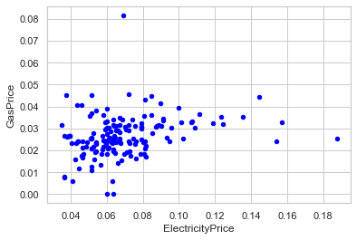

```python
df_work.plot(kind='scatter', x = "ElectricityPrice", y ="GasPrice", color = "blue")

plt.show()
```

#### Valores de los precios de la electricidad

Se obtienen los valores del precio de la electricidad que se usarán en apartados posteriores:

```python
electricityPriceValues = df_work.loc[:, "ElectricityPrice"].to_numpy()

display( electricityPriceValues )
```

```
array([0.0598 , 0.0649 , 0.0672 , 0.0817 , 0.058  , 0.0468 , 0.0433 ,
       0.0406 , 0.081  , 0.1541 , 0.0641 , 0.05895, 0.0574 , 0.0536 ,
       0.0959 , 0.0949 , 0.0461 , 0.0581 , 0.0515 , 0.0675 , 0.0517 ,
       0.05895, 0.0629 , 0.0599 , 0.0468 , 0.0364 , 0.0348 , 0.044  ,
       0.0464 , 0.0533 , 0.05895, 0.0871 , 0.061  , 0.0621 , 0.0624 ,
       0.081  , 0.0602 , 0.0612 , 0.0514 , 0.0489 , 0.0876 , 0.1877 ,
       0.0636 , 0.0364 , 0.0613 , 0.0573 , 0.1091 , 0.1022 , 0.0488 ,
       0.058  , 0.054  , 0.0646 , 0.0505 , 0.0602 , 0.0609 , 0.0593 ,
       0.0539 , 0.0389 , 0.0434 , 0.051  , 0.0526 , 0.0446 , 0.0602 ,
       0.1015 , 0.0654 , 0.0624 , 0.0663 , 0.0764 , 0.0721 , 0.0525 ,
       0.0517 , 0.0516 , 0.0912 , 0.1242 , 0.0685 , 0.0363 , 0.0756 ,
       0.0695 , 0.1236 , 0.1112 , 0.0542 , 0.0615 , 0.0597 , 0.0609 ,
       0.0515 , 0.0636 , 0.0602 , 0.0674 , 0.0636 , 0.0395 , 0.0462 ,
       0.0577 , 0.0633 , 0.066  , 0.0636 , 0.0912 , 0.0702 , 0.0648 ,
       0.0745 , 0.073  , 0.0811 , 0.0651 , 0.0426 , 0.044  , 0.0933 ,
       0.0854 , 0.0757 , 0.0413 , 0.0728 , 0.068  , 0.1189 , 0.1067 ,
       0.0473 , 0.0607 , 0.0567 , 0.0637 , 0.054  , 0.067  , 0.067  ,
       0.0806 , 0.0711 , 0.0393 , 0.0373 , 0.0639 , 0.0721 , 0.0516 ,
       0.0599 , 0.067  , 0.0723 , 0.0793 , 0.089  , 0.1075 , 0.0848 ,
       0.0707 , 0.0898 , 0.085  , 0.1444 , 0.0901 , 0.0793 , 0.0634 ,
       0.0818 , 0.0762 , 0.1571 , 0.1353 , 0.0809 , 0.072  , 0.0787 ,
       0.0542 , 0.0996 , 0.0793 , 0.0651 , 0.0744 , 0.0801 , 0.0379 ,
       0.0692 , 0.0641 , 0.0725 , 0.0518 , 0.0793 , 0.0793 ])
```

#### Valores de los precios del gas

Se obtienen los valores del precio de la gas que se usarńa en apartados posteriores:

```python
gasPriceValues = df_work.loc[:, "GasPrice"].to_numpy()

display( gasPriceValues )
```

```
array([0.0299 , 0.024  , 0.0283 , 0.017  , 0.036  , 0.0243 , 0.0234 ,
       0.0234 , 0.0243 , 0.0243 , 0.031  , 0.0243 , 0.0206 , 0.019  ,
       0.0302 , 0.0243 , 0.0174 , 0.0216 , 0.0207 , 0.0234 , 0.0371 ,
       0.0293 , 0.0237 , 0.0333 , 0.0168 , 0.0264 , 0.0314 , 0.0243 ,
       0.0213 , 0.0159 , 0.0243 , 0.0308 , 0.0304 , 0.024  , 0.0288 ,
       0.0209 , 0.039  , 0.0254 , 0.0259 , 0.0239 , 0.0311 , 0.0254 ,
       0.0317 , 0.008  , 0.0212 , 0.0183 , 0.0304 , 0.0254 , 0.0216 ,
       0.0245 , 0.023  , 0.0186 , 0.0357 , 0.0305 , 0.0246 , 0.0326 ,
       0.0197 , 0.0266 , 0.0405 , 0.0255 , 0.0218 , 0.0118 , 0.     ,
       0.0329 , 0.0312 , 0.0249 , 0.0289 , 0.024  , 0.0455 , 0.0278 ,
       0.0209 , 0.0253 , 0.0338 , 0.0318 , 0.0342 , 0.0075 , 0.0229 ,
       0.0184 , 0.0351 , 0.0366 , 0.0238 , 0.0258 , 0.0227 , 0.021  ,
       0.0454 , 0.0339 , 0.0274 , 0.0347 , 0.0204 , 0.0267 , 0.0405 ,
       0.0267 , 0.0234 , 0.0142 , 0.     , 0.0346 , 0.0308 , 0.0258 ,
       0.0252 , 0.0177 , 0.0431 , 0.0292 , 0.016  , 0.024  , 0.0258 ,
       0.0277 , 0.031  , 0.0059 , 0.0234 , 0.0156 , 0.0325 , 0.0327 ,
       0.0183 , 0.0212 , 0.0133 , 0.0194 , 0.038  , 0.0316 , 0.0243 ,
       0.0357 , 0.0192 , 0.0265 , 0.045  , 0.0254 , 0.024  , 0.0126 ,
       0.0183 , 0.02555, 0.0316 , 0.0251 , 0.0315 , 0.0331 , 0.0448 ,
       0.0293 , 0.0415 , 0.0361 , 0.0444 , 0.0313 , 0.0325 , 0.0058 ,
       0.0221 , 0.0164 , 0.0328 , 0.0354 , 0.0182 , 0.0291 , 0.0184 ,
       0.0232 , 0.0396 , 0.03   , 0.0236 , 0.0341 , 0.0237 , 0.0263 ,
       0.0817 , 0.0264 , 0.0195 , 0.011  , 0.0306 , 0.0306 ])
```

## 4. Análisis de la normalidad y homogeneidad

### Normalidad de la muestra General

#### Análisis gráfico

Se crean los gráficos cuartil-cuartil para ver cuanto se aproximan a la normalidad ambas distribuciones

##### **Precios de la electricidad**

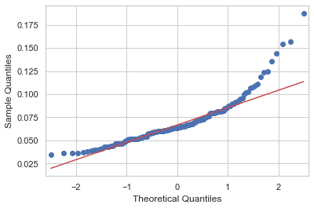

```python
sm.qqplot( electricityPriceValues, line='q' )

plt.show()
```

*Se puede ver que existe valores centrales de la muestra que si se ajusta a una distribución normal.*

##### **Precios del gas**

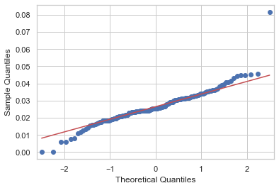

```python
fig2 = sm.qqplot( gasPriceValues, line='q' )
plt.show()
```

*Exactamente que en el caso anterior.*

##### **Preparamos los datasets para trabajar en profundidad**

```python
electricity = ElectPricesHouseholds[["country_name", "2017", "2018", "2019", "2020", "2021"]]
gas = GasPricesHousehold[["country_name", "2017", "2018", "2019", "2020", "2021"]]
```

```python
gas.loc[gas.country_name == "Germany (until 1990 former territory of the FRG)", "country_name"] = 'Germany'
electricity.loc[electricity.country_name == "Germany (until 1990 former territory of the FRG)", "country_name"] = 'Germany'

gas.loc[gas.country_name == "European Union - 27 countries (from 2020)", "country_name"] = 'EU Country'
electricity.loc[electricity.country_name == "European Union - 27 countries (from 2020)", "country_name"] = 'EU Country'

gas.loc[gas.country_name == "Euro area (EA11-1999, EA12-2001, EA13-2007, EA15-2008, EA16-2009, EA17-2011, EA18-2014, EA19-2015)", "country_name"] = 'EU Area'
electricity.loc[electricity.country_name == "Euro area (EA11-1999, EA12-2001, EA13-2007, EA15-2008, EA16-2009, EA17-2011, EA18-2014, EA19-2015)", "country_name"] = 'EU Area'

gas.loc[gas.country_name == "Kosovo (under United Nations Security Council Resolution 1244/99)", "country_name"] = 'Kosovo'
electricity.loc[electricity.country_name == "Kosovo (under United Nations Security Council Resolution 1244/99)", "country_name"] = 'Kosovo'
```

```python
gas_countries = gas.country_name.values
electric_countries = electricity.country_name.values
countries_both = [x for x in gas_countries if x in electric_countries]
electricity = electricity[electricity.country_name.isin(countries_both)]
gas = gas[gas.country_name.isin(countries_both)]
```

```python
pivoted_gas = pd.pivot_table(gas, columns = "country_name")
pivoted_electricity = pd.pivot_table(electricity, columns = "country_name")
```

### 4.1. Aplicación de pruebas estadísticas de forma generel y en profundidad

*Pasamos a realizar los contrastes de hipótesis básicos para analizar el valor estadístico de calidad de la muestra*

```python
def check_normality(df):
    groups = np.array([])
    for group in df.columns:
        groups = np.append(groups, df[group].values)
    stat, p = shapiro(groups[~np.isnan(groups)])
    print(f"Test shapiro, estadistico {stat} y pvalor {p}, H0 los datos siguen una distribucion normal\n")
    if p < 0.05:
        print(f"Probablemente los datos NO siguen una normal")
    else:
        print(f"Probablemente los datos SI siguen una normal")


def check_preconditions(df1, df2):
    print("-"*70)
    print("Checkeando normalidad para todo el dataframe")
    print("-"*70)
    print(f"Primer dataframe:")
    check_normality(df1)
    print("-"*70)
    print(f"Segundo dataframe:")
    check_normality(df2)
    print()
    print("-"*70)
    print("Checkeando homogeneidad de la varianza para los dos datasets")
    print("-"*70)
    check_homo_var(df1, df2)
```

```python
check_preconditions(pivoted_electricity, pivoted_gas)
```

```
----------------------------------------------------------------------
Checkeando normalidad para todo el dataframe
----------------------------------------------------------------------
Primer dataframe:
Test shapiro, estadistico 0.868183970451355 y pvalor 4.7169740335917254e-11, H0 los datos siguen una distribucion normal

Probablemente los datos NO siguen una normal
----------------------------------------------------------------------
Segundo dataframe:
Test shapiro, estadistico 0.9178404808044434 y pvalor 3.387682312450124e-08, H0 los datos siguen una distribucion normal

Probablemente los datos NO siguen una normal

----------------------------------------------------------------------
Checkeando homogeneidad de la varianza para los dos datasets
----------------------------------------------------------------------
Bartlett test para, H0 los datos tienen homogeneidad en las varianzas

Test bartlett, estadistico 130.8732383104749 y pvalor 2.6393361755798005e-30
Probablemente NO homogeneidad en las varianzas
```

```python
def check_normality_each_country(df):
    for col in df.columns:
        stat, p = shapiro(df[col])
        print("-"*70)
        print(f"Test para {col}:")
        print(f"Test shapiro, estadistico {stat} y pvalor {p}, H0 los datos siguen una distribucion normal\n")
        if p < 0.05:
            print(f"Probablemente los datos NO siguen una normal\n")
        else:
            print(f"Probablemente los datos SI siguen una normal\n")
```

```python
check_normality_each_country(pivoted_gas)
```

```
----------------------------------------------------------------------
Test para Austria:
Test shapiro, estadistico 0.9899673461914062 y pvalor 0.9795799851417542, H0 los datos siguen una distribucion normal

Probablemente los datos SI siguen una normal

----------------------------------------------------------------------
Test para Belgium:
Test shapiro, estadistico 0.9303292632102966 y pvalor 0.5986178517341614, H0 los datos siguen una distribucion normal

Probablemente los datos SI siguen una normal

----------------------------------------------------------------------
Test para Bosnia and Herzegovina:
Test shapiro, estadistico 0.9009255766868591 y pvalor 0.41502219438552856, H0 los datos siguen una distribucion normal

Probablemente los datos SI siguen una normal

----------------------------------------------------------------------
Test para Bulgaria:
Test shapiro, estadistico 0.8762538433074951 y pvalor 0.2926786243915558, H0 los datos siguen una distribucion normal

Probablemente los datos SI siguen una normal

----------------------------------------------------------------------
Test para Croatia:
Test shapiro, estadistico 0.9603146910667419 y pvalor 0.8101732134819031, H0 los datos siguen una distribucion normal

Probablemente los datos SI siguen una normal

----------------------------------------------------------------------
Test para Czechia:
Test shapiro, estadistico 0.9044991731643677 y pvalor 0.43524986505508423, H0 los datos siguen una distribucion normal

Probablemente los datos SI siguen una normal

----------------------------------------------------------------------
Test para Denmark:
Test shapiro, estadistico 0.8861088752746582 y pvalor 0.3379155099391937, H0 los datos siguen una distribucion normal

```

[output cut: 148 more lines]

```
Test shapiro, estadistico 0.9555109143257141 y pvalor 0.7764301300048828, H0 los datos siguen una distribucion normal

Probablemente los datos SI siguen una normal

----------------------------------------------------------------------
Test para Ukraine:
Test shapiro, estadistico 0.8690097332000732 y pvalor 0.26243698596954346, H0 los datos siguen una distribucion normal

Probablemente los datos SI siguen una normal

----------------------------------------------------------------------
Test para United Kingdom:
Test shapiro, estadistico 0.9300695657730103 y pvalor 0.5968450903892517, H0 los datos siguen una distribucion normal

Probablemente los datos SI siguen una normal
```

*Efectivamente tal y como nos hizo sospechar las gráficas inciales si encontramos países cuyos precios se ajustan a la normalidad.*

### 5.2 Estudio de la correlación

```python
def check_homo_var(df1, df2):
    group1 = np.array([])
    for group in df1.columns:
        group1 = np.append(group1, df1[group].values)
    group2 = np.array([])
    for group in df2.columns:
        group2 = np.append(group2, df2[group].values)
    stat, p = bartlett(group1[~np.isnan(group1)], group2[~np.isnan(group2)])

    print(f"Bartlett test para, H0 los datos tienen homogeneidad en las varianzas\n")
    print(f"Test bartlett, estadistico {stat} y pvalor {p}")
    if p < 0.05:
        print(f"Probablemente NO homogeneidad en las varianzas\n")
    else:
        print(f"Probablemente SI homogeneidad en las varianzas\n")


def check_correlation(df1, df2):
    group1 = np.array([])
    for group in df1.columns:
        group1 = np.append(group1, df1[group].values)
    group2 = np.array([])
    for group in df2.columns:
        group2 = np.append(group2, df2[group].values)

    indxs1 = np.isnan(group1)
    indxs2 = np.isnan(group2)
    indxs = indxs1 | indxs2 # indices que tienen nan en alguno de los dos df

    group1 = group1[~indxs]
    group2 = group2[~indxs]

    stat, p = pearsonr(group1, group2)
    print(f"Test pearson, estadistico {stat} y pvalor {p}, H0 no estan correlacionadas\n")
    if p < 0.05:
        print(f"Probablemente NO estan correlacionados\n")
    else:
        print(f"Probablemente SI estan correlacionados\n")
```

```python
check_homo_var(pivoted_electricity, pivoted_gas)
check_correlation(pivoted_electricity, pivoted_gas)
```

```
Bartlett test para, H0 los datos tienen homogeneidad en las varianzas

Test bartlett, estadistico 130.8732383104749 y pvalor 2.6393361755798005e-30
Probablemente NO homogeneidad en las varianzas

Test pearson, estadistico 0.282540907419713 y pvalor 0.00018917062353675837, H0 no estan correlacionadas

Probablemente NO estan correlacionados
```

```python
def plot_countries(gas, electricity, names):
    fig, axs = plt.subplots(5, 8, figsize=(20,15), sharex=True)
    k = 0
    for i in range(5):
        for j in range(8):
            if k == len(names):
                fig.delaxes(axs[i][j])
                continue
            axs[i][j].plot(pivoted_gas.index, pivoted_gas[names[k]], color = 'r')
            axs[i][j].plot(pivoted_electricity.index, pivoted_electricity[names[k]], color = 'g')
            axs[i][j].set_title(f"{names[k]}")
            k += 1
    fig.legend(['Precio del gas en dolares', 'Precio de la electricidad en dolares'], loc='upper right')
    fig.suptitle("Precio del gas y de la electricidad desde 2017 hasta 2021")
    plt.show()
```

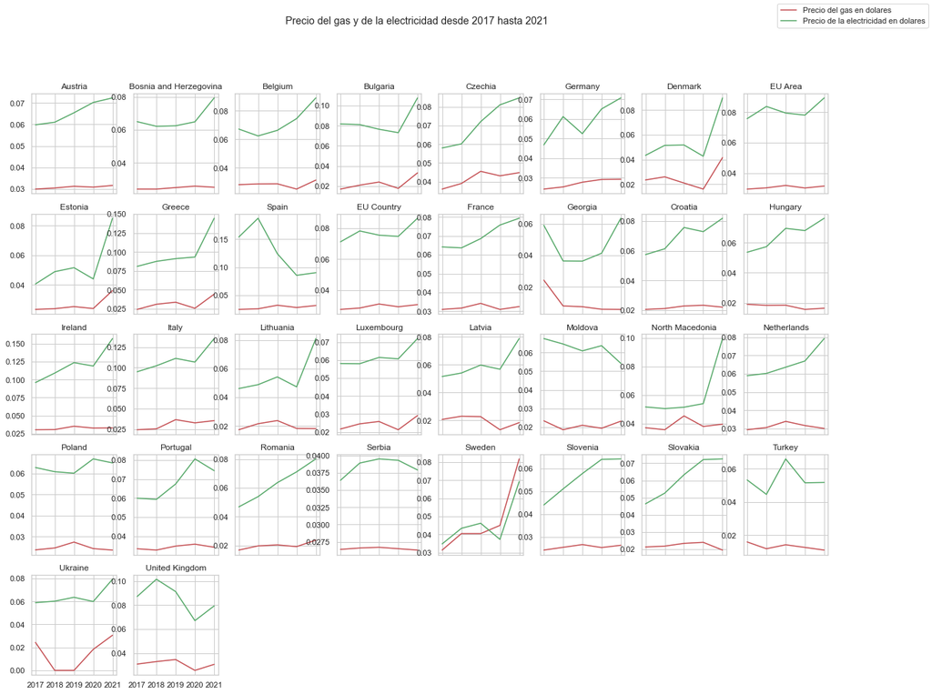

```python
plot_countries(pivoted_gas, pivoted_electricity, countries_both)
```

*Aparentemente vemos correlación directa e inversa en los conjuntos por países, pasamos a chequear.*

```python
def check_homo_var_each_country(df1, df2):
    group1 = np.array([])
    group2 = np.array([])
    for group in df1.columns:
        group1 = np.append(group1, df1[group].values)
        group2 = np.append(group2, df2[group].values)
        stat, p = bartlett(group1[~np.isnan(group1)], group2[~np.isnan(group2)])
        print("-"*70)
        print(f"Bartlett test para {group}, H0 los datos tienen homogeneidad en las varianzas\n")
        print(f"Estadistico {stat} y pvalor {p}")
        if p < 0.05:
            print(f"probablemente NO homogeneidad en las varianzas")
        else:
            print(f"probablemente SI homogeneidad en las varianzas")
        print("-"*70)
```

```python
check_homo_var_each_country(pivoted_gas, pivoted_electricity)
```

```
----------------------------------------------------------------------
Bartlett test para Austria, H0 los datos tienen homogeneidad en las varianzas

Estadistico 10.193735212469518 y pvalor 0.0014091858076003634
probablemente NO homogeneidad en las varianzas
----------------------------------------------------------------------
----------------------------------------------------------------------
Bartlett test para Belgium, H0 los datos tienen homogeneidad en las varianzas

Estadistico 14.191634787699723 y pvalor 0.00016510287297749078
probablemente NO homogeneidad en las varianzas
----------------------------------------------------------------------
----------------------------------------------------------------------
Bartlett test para Bosnia and Herzegovina, H0 los datos tienen homogeneidad en las varianzas

Estadistico 11.896558954264867 y pvalor 0.0005623773997189065
probablemente NO homogeneidad en las varianzas
----------------------------------------------------------------------
----------------------------------------------------------------------
Bartlett test para Bulgaria, H0 los datos tienen homogeneidad en las varianzas

Estadistico 14.074119370282013 y pvalor 0.00017574544528976732
probablemente NO homogeneidad en las varianzas
----------------------------------------------------------------------
----------------------------------------------------------------------
Bartlett test para Croatia, H0 los datos tienen homogeneidad en las varianzas

Estadistico 17.06256083524616 y pvalor 3.616834643278469e-05
probablemente NO homogeneidad en las varianzas
----------------------------------------------------------------------
----------------------------------------------------------------------
Bartlett test para Czechia, H0 los datos tienen homogeneidad en las varianzas

Estadistico 4.3748755932672685 y pvalor 0.03647249268879289
probablemente NO homogeneidad en las varianzas
----------------------------------------------------------------------
----------------------------------------------------------------------
Bartlett test para Denmark, H0 los datos tienen homogeneidad en las varianzas

Estadistico 9.901057401760188 y pvalor 0.0016518383204098415
```

[output cut: 149 more lines]

```
Estadistico 134.82911528249795 y pvalor 3.598441199985169e-31
probablemente NO homogeneidad en las varianzas
----------------------------------------------------------------------
----------------------------------------------------------------------
Bartlett test para Ukraine, H0 los datos tienen homogeneidad en las varianzas

Estadistico 125.62764519962633 y pvalor 3.7094553526048056e-29
probablemente NO homogeneidad en las varianzas
----------------------------------------------------------------------
----------------------------------------------------------------------
Bartlett test para United Kingdom, H0 los datos tienen homogeneidad en las varianzas

Estadistico 130.8732383104749 y pvalor 2.6393361755798005e-30
probablemente NO homogeneidad en las varianzas
----------------------------------------------------------------------
```

*Efectivamente, volvemos a obtener heterocedasticidad, diferencia de varianzas en las muestras, esto es un problema, deberíamos trabajar las muestras más a profundidad para intentar solventarla, pero se sale de scope. Vamos, aún así, a estudiar la correlación.*

```python
def check_correlation_each_country(df1, df2):
    group1 = np.array([])
    group2 = np.array([])
    for group in df1.columns:
        group1 = np.append(group1, df1[group].values)
        group2 = np.append(group2, df2[group].values)

        indxs1 = np.isnan(group1)
        indxs2 = np.isnan(group2)
        indxs = indxs1 | indxs2 # indices que tienen nan en alguno de los dos df

        group1 = group1[~indxs]
        group2 = group2[~indxs]

        stat, p = pearsonr(group1, group2)
        print(f"Test pearson para {group}, estadistico {stat} y pvalor {p}, H0 no estan correlacionadas\n")
        if p < 0.05:
            print(f"Probablemente NO estan correlacionados")
        else:
            print(f"Probablemente SI esten correlacionados")
```

```python
check_correlation_each_country(pivoted_electricity, pivoted_gas)
```

```
Test pearson para Austria, estadistico 0.845371068323818 y pvalor 0.07127402761509678, H0 no estan correlacionadas

Probablemente SI esten correlacionados
Test pearson para Belgium, estadistico 0.10983703213365414 y pvalor 0.7626092116466721, H0 no estan correlacionadas

Probablemente SI esten correlacionados
Test pearson para Bosnia and Herzegovina, estadistico 0.17972750265742504 y pvalor 0.5215576763339973, H0 no estan correlacionadas

Probablemente SI esten correlacionados
Test pearson para Bulgaria, estadistico 0.03969110130797798 y pvalor 0.8680472606214779, H0 no estan correlacionadas

Probablemente SI esten correlacionados
Test pearson para Croatia, estadistico 0.09655801836832324 y pvalor 0.6461275439071115, H0 no estan correlacionadas

Probablemente SI esten correlacionados
Test pearson para Czechia, estadistico 0.1070330077542502 y pvalor 0.5734656580929945, H0 no estan correlacionadas

Probablemente SI esten correlacionados
Test pearson para Denmark, estadistico 0.32926913448388684 y pvalor 0.05342336639497488, H0 no estan correlacionadas

Probablemente SI esten correlacionados
Test pearson para EU Area, estadistico 0.34884885671723004 y pvalor 0.027371765263910254, H0 no estan correlacionadas

Probablemente NO estan correlacionados
Test pearson para EU Country, estadistico 0.352600600833549 y pvalor 0.017519783852434266, H0 no estan correlacionadas

Probablemente NO estan correlacionados
Test pearson para Estonia, estadistico 0.40591687758966166 y pvalor 0.003447589877845323, H0 no estan correlacionadas

Probablemente NO estan correlacionados
Test pearson para France, estadistico 0.39786027127426865 y pvalor 0.002628949607816149, H0 no estan correlacionadas

Probablemente NO estan correlacionados
Test pearson para Georgia, estadistico 0.5446619100188149 y pvalor 6.828305061520844e-06, H0 no estan correlacionadas

Probablemente NO estan correlacionados
Test pearson para Germany, estadistico 0.5368738523807763 y pvalor 4.018864397349724e-06, H0 no estan correlacionadas

Probablemente NO estan correlacionados
Test pearson para Greece, estadistico 0.5641819868327069 y pvalor 3.6508282561000874e-07, H0 no estan correlacionadas
```

[output cut: 47 more lines]

```
Test pearson para Spain, estadistico 0.369728498662823 y pvalor 3.2173755292893473e-06, H0 no estan correlacionadas

Probablemente NO estan correlacionados
Test pearson para Sweden, estadistico 0.2521460028362418 y pvalor 0.0015503878409114694, H0 no estan correlacionadas

Probablemente NO estan correlacionados
Test pearson para Turkey, estadistico 0.27413483078256173 y pvalor 0.00045179839914571816, H0 no estan correlacionadas

Probablemente NO estan correlacionados
Test pearson para Ukraine, estadistico 0.27310465067688705 y pvalor 0.00038649595749785427, H0 no estan correlacionadas

Probablemente NO estan correlacionados
Test pearson para United Kingdom, estadistico 0.282540907419713 y pvalor 0.00018917062353675837, H0 no estan correlacionadas

Probablemente NO estan correlacionados
```